# Risk Factor Analysis

## Outcome Variable

**Outcome Variable:** stunted

## Predictor Variables

**Intervention Variable:** impsan

**Adjustment Set:**

unadjusted

## Stratifying Variables

The analysis was stratified on these variable(s):

- agecat
- studyid
- country

## Data Summary

| agecat | studyid | country | impsan | stunted | n_cell | n |
| --- | --- | --- | --- | --- | --- | --- |
| Birth | ki0047075b-MAL-ED | BANGLADESH | 0 | 0 | 32 | 234 |
| Birth | ki0047075b-MAL-ED | BANGLADESH | 0 | 1 | 5 | 234 |
| Birth | ki0047075b-MAL-ED | BANGLADESH | 1 | 0 | 164 | 234 |
| Birth | ki0047075b-MAL-ED | BANGLADESH | 1 | 1 | 33 | 234 |
| 6 months | ki0047075b-MAL-ED | BANGLADESH | 0 | 0 | 33 | 240 |
| 6 months | ki0047075b-MAL-ED | BANGLADESH | 0 | 1 | 5 | 240 |
| 6 months | ki0047075b-MAL-ED | BANGLADESH | 1 | 0 | 162 | 240 |
| 6 months | ki0047075b-MAL-ED | BANGLADESH | 1 | 1 | 40 | 240 |
| 24 months | ki0047075b-MAL-ED | BANGLADESH | 0 | 0 | 16 | 212 |
| 24 months | ki0047075b-MAL-ED | BANGLADESH | 0 | 1 | 15 | 212 |
| 24 months | ki0047075b-MAL-ED | BANGLADESH | 1 | 0 | 98 | 212 |
| 24 months | ki0047075b-MAL-ED | BANGLADESH | 1 | 1 | 83 | 212 |
| Birth | ki0047075b-MAL-ED | BRAZIL | 0 | 0 | 4 | 174 |
| Birth | ki0047075b-MAL-ED | BRAZIL | 0 | 1 | 0 | 174 |
| Birth | ki0047075b-MAL-ED | BRAZIL | 1 | 0 | 153 | 174 |
| Birth | ki0047075b-MAL-ED | BRAZIL | 1 | 1 | 17 | 174 |
| 6 months | ki0047075b-MAL-ED | BRAZIL | 0 | 0 | 4 | 209 |
| 6 months | ki0047075b-MAL-ED | BRAZIL | 0 | 1 | 0 | 209 |
| 6 months | ki0047075b-MAL-ED | BRAZIL | 1 | 0 | 199 | 209 |
| 6 months | ki0047075b-MAL-ED | BRAZIL | 1 | 1 | 6 | 209 |
| 24 months | ki0047075b-MAL-ED | BRAZIL | 0 | 0 | 3 | 169 |
| 24 months | ki0047075b-MAL-ED | BRAZIL | 0 | 1 | 0 | 169 |
| 24 months | ki0047075b-MAL-ED | BRAZIL | 1 | 0 | 160 | 169 |
| 24 months | ki0047075b-MAL-ED | BRAZIL | 1 | 1 | 6 | 169 |
| Birth | ki0047075b-MAL-ED | INDIA | 0 | 0 | 85 | 190 |
| Birth | ki0047075b-MAL-ED | INDIA | 0 | 1 | 13 | 190 |
| Birth | ki0047075b-MAL-ED | INDIA | 1 | 0 | 76 | 190 |
| Birth | ki0047075b-MAL-ED | INDIA | 1 | 1 | 16 | 190 |
| 6 months | ki0047075b-MAL-ED | INDIA | 0 | 0 | 98 | 233 |
| 6 months | ki0047075b-MAL-ED | INDIA | 0 | 1 | 27 | 233 |

[output cut: 158 more lines]

The following strata were considered:

- agecat: 24 months, studyid: ki0047075b-MAL-ED, country: BANGLADESH
- agecat: 24 months, studyid: ki0047075b-MAL-ED, country: BRAZIL
- agecat: 24 months, studyid: ki0047075b-MAL-ED, country: INDIA
- agecat: 24 months, studyid: ki0047075b-MAL-ED, country: NEPAL
- agecat: 24 months, studyid: ki0047075b-MAL-ED, country: PERU
- agecat: 24 months, studyid: ki0047075b-MAL-ED, country: SOUTH AFRICA
- agecat: 24 months, studyid: ki0047075b-MAL-ED, country: TANZANIA, UNITED REPUBLIC OF
- agecat: 24 months, studyid: ki1017093-NIH-Birth, country: BANGLADESH
- agecat: 24 months, studyid: ki1017093b-PROVIDE, country: BANGLADESH
- agecat: 24 months, studyid: ki1017093c-NIH-Crypto, country: BANGLADESH
- agecat: 24 months, studyid: ki1114097-CONTENT, country: PERU
- agecat: 24 months, studyid: ki1135781-COHORTS, country: GUATEMALA
- agecat: 24 months, studyid: ki1135781-COHORTS, country: INDIA
- agecat: 24 months, studyid: ki1135781-COHORTS, country: PHILIPPINES
- agecat: 24 months, studyid: ki1148112-LCNI-5, country: MALAWI
- agecat: 24 months, studyid: kiGH5241-JiVitA-3, country: BANGLADESH
- agecat: 24 months, studyid: kiGH5241-JiVitA-4, country: BANGLADESH
- agecat: 6 months, studyid: ki0047075b-MAL-ED, country: BANGLADESH
- agecat: 6 months, studyid: ki0047075b-MAL-ED, country: BRAZIL
- agecat: 6 months, studyid: ki0047075b-MAL-ED, country: INDIA
- agecat: 6 months, studyid: ki0047075b-MAL-ED, country: NEPAL
- agecat: 6 months, studyid: ki0047075b-MAL-ED, country: PERU
- agecat: 6 months, studyid: ki0047075b-MAL-ED, country: SOUTH AFRICA
- agecat: 6 months, studyid: ki0047075b-MAL-ED, country: TANZANIA, UNITED REPUBLIC OF
- agecat: 6 months, studyid: ki1017093-NIH-Birth, country: BANGLADESH
- agecat: 6 months, studyid: ki1017093b-PROVIDE, country: BANGLADESH
- agecat: 6 months, studyid: ki1017093c-NIH-Crypto, country: BANGLADESH
- agecat: 6 months, studyid: ki1114097-CONTENT, country: PERU
- agecat: 6 months, studyid: ki1135781-COHORTS, country: GUATEMALA
- agecat: 6 months, studyid: ki1135781-COHORTS, country: INDIA
- agecat: 6 months, studyid: ki1135781-COHORTS, country: PHILIPPINES
- agecat: 6 months, studyid: ki1148112-LCNI-5, country: MALAWI
- agecat: 6 months, studyid: kiGH5241-JiVitA-3, country: BANGLADESH
- agecat: 6 months, studyid: kiGH5241-JiVitA-4, country: BANGLADESH
- agecat: Birth, studyid: ki0047075b-MAL-ED, country: BANGLADESH
- agecat: Birth, studyid: ki0047075b-MAL-ED, country: BRAZIL
- agecat: Birth, studyid: ki0047075b-MAL-ED, country: INDIA
- agecat: Birth, studyid: ki0047075b-MAL-ED, country: NEPAL
- agecat: Birth, studyid: ki0047075b-MAL-ED, country: PERU
- agecat: Birth, studyid: ki0047075b-MAL-ED, country: SOUTH AFRICA
- agecat: Birth, studyid: ki0047075b-MAL-ED, country: TANZANIA, UNITED REPUBLIC OF
- agecat: Birth, studyid: ki1017093-NIH-Birth, country: BANGLADESH
- agecat: Birth, studyid: ki1017093c-NIH-Crypto, country: BANGLADESH
- agecat: Birth, studyid: ki1114097-CONTENT, country: PERU
- agecat: Birth, studyid: ki1135781-COHORTS, country: GUATEMALA
- agecat: Birth, studyid: ki1135781-COHORTS, country: INDIA
- agecat: Birth, studyid: ki1135781-COHORTS, country: PHILIPPINES
- agecat: Birth, studyid: kiGH5241-JiVitA-3, country: BANGLADESH
- agecat: Birth, studyid: kiGH5241-JiVitA-4, country: BANGLADESH

### Dropped Strata

Some strata were dropped due to rare outcomes:

- agecat: Birth, studyid: ki0047075b-MAL-ED, country: BRAZIL
- agecat: 6 months, studyid: ki0047075b-MAL-ED, country: BRAZIL
- agecat: 24 months, studyid: ki0047075b-MAL-ED, country: BRAZIL
- agecat: 6 months, studyid: ki0047075b-MAL-ED, country: NEPAL
- agecat: 24 months, studyid: ki0047075b-MAL-ED, country: NEPAL
- agecat: Birth, studyid: ki0047075b-MAL-ED, country: NEPAL
- agecat: Birth, studyid: ki0047075b-MAL-ED, country: SOUTH AFRICA
- agecat: 6 months, studyid: ki0047075b-MAL-ED, country: SOUTH AFRICA
- agecat: 24 months, studyid: ki0047075b-MAL-ED, country: SOUTH AFRICA
- agecat: Birth, studyid: ki1017093-NIH-Birth, country: BANGLADESH
- agecat: Birth, studyid: ki1017093c-NIH-Crypto, country: BANGLADESH
- agecat: 6 months, studyid: ki1114097-CONTENT, country: PERU
- agecat: 24 months, studyid: ki1114097-CONTENT, country: PERU
- agecat: Birth, studyid: ki1114097-CONTENT, country: PERU
- agecat: Birth, studyid: ki1135781-COHORTS, country: GUATEMALA
- agecat: Birth, studyid: ki1135781-COHORTS, country: PHILIPPINES
- agecat: 6 months, studyid: ki1148112-LCNI-5, country: MALAWI
- agecat: 24 months, studyid: ki1148112-LCNI-5, country: MALAWI

## Methods Detail

We’re interested in the causal parameters $E[Y_a]$ for all values of $a \in \mathcal{A}$. These parameters represent the mean outcome if, possibly contrary to fact, we intervened to set all units to have $A=a$. Under the randomization and positivity assumptions, these are identified by the statistical parameters $\psi_a=E_W[E_{Y|A,W}(Y|A=a,W)]$. In addition, we’re interested in the mean of $Y$, $E[Y]$ under no intervention (the observed mean). We will estimate these parameters by using SuperLearner to fit the relevant likelihood factors – $E_{Y|A,W}(Y|A=a,W)$ and $p(A=a|W)$, and then updating our likelihood fit using a joint TMLE.

For unadjusted analyses ($W=\{\}$), initial likelihoods were estimated using Lrnr_glm to estimate the simple $E(Y|A)$ and Lrnr_mean to estimate $p(A)$. For adjusted analyses, a small library containing Lrnr_glmnet, Lrnr_xgboost, and Lrnr_mean was used.

Having estimated these parameters, we will then use the delta method to estimate relative risks and attributable risks relative to a prespecified baseline level of $A$.

```
##       stunted
## impsan   0   1
##      0  58 149
##      1   0   0
##       stunted
## impsan   0   1
##      0 181  57
##      1   0   0
##       stunted
## impsan  0  1
##      0 97 16
##      1  0  0
```

# Results Detail

## Results Plots

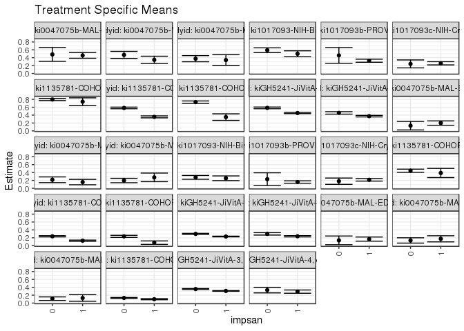

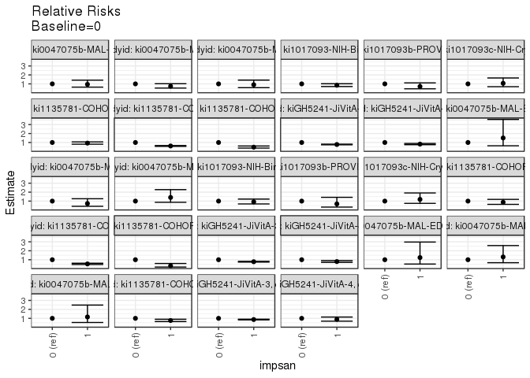

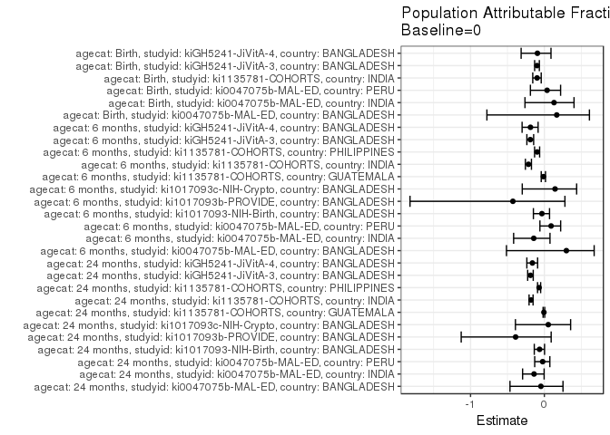

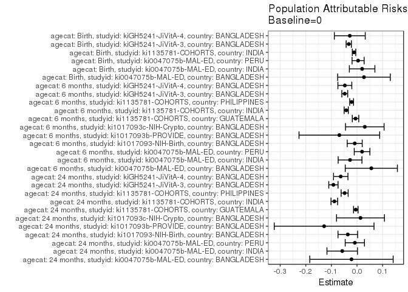

## Results Table

### Parameter: TSM

| agecat | studyid | country | intervention_level | baseline_level | estimate | ci_lower | ci_upper |
| --- | --- | --- | --- | --- | --- | --- | --- |
| Birth | ki0047075b-MAL-ED | BANGLADESH | 0 | NA | 0.1351351 | 0.0247437 | 0.2455266 |
| Birth | ki0047075b-MAL-ED | BANGLADESH | 1 | NA | 0.1675127 | 0.1152541 | 0.2197713 |
| Birth | ki0047075b-MAL-ED | INDIA | 0 | NA | 0.1326531 | 0.0653188 | 0.1999873 |
| Birth | ki0047075b-MAL-ED | INDIA | 1 | NA | 0.1739130 | 0.0962563 | 0.2515698 |
| Birth | ki0047075b-MAL-ED | PERU | 0 | NA | 0.1117021 | 0.0665842 | 0.1568201 |
| Birth | ki0047075b-MAL-ED | PERU | 1 | NA | 0.1290323 | 0.0454195 | 0.2126451 |
| Birth | ki1135781-COHORTS | INDIA | 0 | NA | 0.1299435 | 0.1179282 | 0.1419588 |
| Birth | ki1135781-COHORTS | INDIA | 1 | NA | 0.0984720 | 0.0845782 | 0.1123658 |
| Birth | kiGH5241-JiVitA-3 | BANGLADESH | 0 | NA | 0.3555035 | 0.3428552 | 0.3681518 |
| Birth | kiGH5241-JiVitA-3 | BANGLADESH | 1 | NA | 0.3077273 | 0.2985190 | 0.3169356 |
| Birth | kiGH5241-JiVitA-4 | BANGLADESH | 0 | NA | 0.3287037 | 0.2582974 | 0.3991100 |
| Birth | kiGH5241-JiVitA-4 | BANGLADESH | 1 | NA | 0.2904290 | 0.2490841 | 0.3317739 |
| 6 months | ki0047075b-MAL-ED | BANGLADESH | 0 | NA | 0.1315789 | 0.0238775 | 0.2392803 |
| 6 months | ki0047075b-MAL-ED | BANGLADESH | 1 | NA | 0.1980198 | 0.1429498 | 0.2530898 |
| 6 months | ki0047075b-MAL-ED | INDIA | 0 | NA | 0.2160000 | 0.1437044 | 0.2882956 |
| 6 months | ki0047075b-MAL-ED | INDIA | 1 | NA | 0.1574074 | 0.0885752 | 0.2262396 |
| 6 months | ki0047075b-MAL-ED | PERU | 0 | NA | 0.1969697 | 0.1414677 | 0.2524717 |
| 6 months | ki0047075b-MAL-ED | PERU | 1 | NA | 0.2769231 | 0.1679321 | 0.3859140 |
| 6 months | ki1017093-NIH-Birth | BANGLADESH | 0 | NA | 0.2771084 | 0.2289197 | 0.3252971 |
| 6 months | ki1017093-NIH-Birth | BANGLADESH | 1 | NA | 0.2536585 | 0.1940416 | 0.3132754 |
| 6 months | ki1017093b-PROVIDE | BANGLADESH | 0 | NA | 0.2307692 | 0.0686805 | 0.3928579 |
| 6 months | ki1017093b-PROVIDE | BANGLADESH | 1 | NA | 0.1585586 | 0.1281439 | 0.1889732 |
| 6 months | ki1017093c-NIH-Crypto | BANGLADESH | 0 | NA | 0.1797753 | 0.0999403 | 0.2596103 |
| 6 months | ki1017093c-NIH-Crypto | BANGLADESH | 1 | NA | 0.2146341 | 0.1821625 | 0.2471058 |
| 6 months | ki1135781-COHORTS | GUATEMALA | 0 | NA | 0.4450085 | 0.4049115 | 0.4851055 |
| 6 months | ki1135781-COHORTS | GUATEMALA | 1 | NA | 0.3880597 | 0.2712861 | 0.5048333 |
| 6 months | ki1135781-COHORTS | INDIA | 0 | NA | 0.2378641 | 0.2228502 | 0.2528780 |
| 6 months | ki1135781-COHORTS | INDIA | 1 | NA | 0.1265284 | 0.1115034 | 0.1415535 |
| 6 months | ki1135781-COHORTS | PHILIPPINES | 0 | NA | 0.2361702 | 0.2090061 | 0.2633343 |
| 6 months | ki1135781-COHORTS | PHILIPPINES | 1 | NA | 0.0769231 | 0.0332285 | 0.1206177 |
| 6 months | kiGH5241-JiVitA-3 | BANGLADESH | 0 | NA | 0.2992440 | 0.2852659 | 0.3132221 |
| 6 months | kiGH5241-JiVitA-3 | BANGLADESH | 1 | NA | 0.2325137 | 0.2233357 | 0.2416917 |
| 6 months | kiGH5241-JiVitA-4 | BANGLADESH | 0 | NA | 0.2997250 | 0.2691771 | 0.3302729 |
| 6 months | kiGH5241-JiVitA-4 | BANGLADESH | 1 | NA | 0.2383503 | 0.2222478 | 0.2544528 |
| 24 months | ki0047075b-MAL-ED | BANGLADESH | 0 | NA | 0.4838710 | 0.3075362 | 0.6602057 |
| 24 months | ki0047075b-MAL-ED | BANGLADESH | 1 | NA | 0.4585635 | 0.3858008 | 0.5313263 |
| 24 months | ki0047075b-MAL-ED | INDIA | 0 | NA | 0.4710744 | 0.3819360 | 0.5602128 |
| 24 months | ki0047075b-MAL-ED | INDIA | 1 | NA | 0.3461538 | 0.2545168 | 0.4377909 |
| 24 months | ki0047075b-MAL-ED | PERU | 0 | NA | 0.3758389 | 0.2978712 | 0.4538067 |
| 24 months | ki0047075b-MAL-ED | PERU | 1 | NA | 0.3404255 | 0.2046089 | 0.4762421 |
| 24 months | ki1017093-NIH-Birth | BANGLADESH | 0 | NA | 0.5907336 | 0.5307816 | 0.6506856 |
| 24 months | ki1017093-NIH-Birth | BANGLADESH | 1 | NA | 0.5000000 | 0.4247511 | 0.5752489 |
| 24 months | ki1017093b-PROVIDE | BANGLADESH | 0 | NA | 0.4583333 | 0.2588179 | 0.6578488 |
| 24 months | ki1017093b-PROVIDE | BANGLADESH | 1 | NA | 0.3242754 | 0.2851915 | 0.3633592 |
| 24 months | ki1017093c-NIH-Crypto | BANGLADESH | 0 | NA | 0.2428571 | 0.1423040 | 0.3434103 |
| 24 months | ki1017093c-NIH-Crypto | BANGLADESH | 1 | NA | 0.2586605 | 0.2173738 | 0.2999472 |
| 24 months | ki1135781-COHORTS | GUATEMALA | 0 | NA | 0.7960928 | 0.7684840 | 0.8237015 |
| 24 months | ki1135781-COHORTS | GUATEMALA | 1 | NA | 0.7402597 | 0.6422641 | 0.8382554 |
| 24 months | ki1135781-COHORTS | INDIA | 0 | NA | 0.5816908 | 0.5614537 | 0.6019278 |
| 24 months | ki1135781-COHORTS | INDIA | 1 | NA | 0.3555404 | 0.3310756 | 0.3800053 |
| 24 months | ki1135781-COHORTS | PHILIPPINES | 0 | NA | 0.7291667 | 0.6995201 | 0.7588133 |
| 24 months | ki1135781-COHORTS | PHILIPPINES | 1 | NA | 0.3492063 | 0.2659255 | 0.4324872 |
| 24 months | kiGH5241-JiVitA-3 | BANGLADESH | 0 | NA | 0.5830346 | 0.5615752 | 0.6044941 |
| 24 months | kiGH5241-JiVitA-3 | BANGLADESH | 1 | NA | 0.4529537 | 0.4377461 | 0.4681613 |
| 24 months | kiGH5241-JiVitA-4 | BANGLADESH | 0 | NA | 0.4558271 | 0.4246101 | 0.4870441 |
| 24 months | kiGH5241-JiVitA-4 | BANGLADESH | 1 | NA | 0.3738800 | 0.3543703 | 0.3933896 |

### Parameter: E(Y)

| agecat | studyid | country | intervention_level | baseline_level | estimate | ci_lower | ci_upper |
| --- | --- | --- | --- | --- | --- | --- | --- |
| Birth | ki0047075b-MAL-ED | BANGLADESH | NA | NA | 0.1623932 | 0.1150373 | 0.2097491 |
| Birth | ki0047075b-MAL-ED | INDIA | NA | NA | 0.1526316 | 0.1013601 | 0.2039030 |
| Birth | ki0047075b-MAL-ED | PERU | NA | NA | 0.1160000 | 0.0762256 | 0.1557744 |
| Birth | ki1135781-COHORTS | INDIA | NA | NA | 0.1182998 | 0.1091394 | 0.1274602 |
| Birth | kiGH5241-JiVitA-3 | BANGLADESH | NA | NA | 0.3233463 | 0.3156839 | 0.3310086 |
| Birth | kiGH5241-JiVitA-4 | BANGLADESH | NA | NA | 0.3004866 | 0.2649179 | 0.3360553 |
| 6 months | ki0047075b-MAL-ED | BANGLADESH | NA | NA | 0.1875000 | 0.1380164 | 0.2369836 |
| 6 months | ki0047075b-MAL-ED | INDIA | NA | NA | 0.1888412 | 0.1384789 | 0.2392035 |
| 6 months | ki0047075b-MAL-ED | PERU | NA | NA | 0.2167300 | 0.1668401 | 0.2666199 |
| 6 months | ki1017093-NIH-Birth | BANGLADESH | NA | NA | 0.2681564 | 0.2306532 | 0.3056597 |
| 6 months | ki1017093b-PROVIDE | BANGLADESH | NA | NA | 0.1617900 | 0.1318200 | 0.1917600 |
| 6 months | ki1017093c-NIH-Crypto | BANGLADESH | NA | NA | 0.2102273 | 0.1801065 | 0.2403480 |
| 6 months | ki1135781-COHORTS | GUATEMALA | NA | NA | 0.4392097 | 0.4012606 | 0.4771588 |
| 6 months | ki1135781-COHORTS | INDIA | NA | NA | 0.1957353 | 0.1847045 | 0.2067660 |
| 6 months | ki1135781-COHORTS | PHILIPPINES | NA | NA | 0.2151431 | 0.1906585 | 0.2396277 |
| 6 months | kiGH5241-JiVitA-3 | BANGLADESH | NA | NA | 0.2514286 | 0.2432891 | 0.2595681 |
| 6 months | kiGH5241-JiVitA-4 | BANGLADESH | NA | NA | 0.2522280 | 0.2381653 | 0.2662906 |
| 24 months | ki0047075b-MAL-ED | BANGLADESH | NA | NA | 0.4622642 | 0.3949918 | 0.5295365 |
| 24 months | ki0047075b-MAL-ED | INDIA | NA | NA | 0.4133333 | 0.3488467 | 0.4778200 |
| 24 months | ki0047075b-MAL-ED | PERU | NA | NA | 0.3673469 | 0.2996839 | 0.4350100 |
| 24 months | ki1017093-NIH-Birth | BANGLADESH | NA | NA | 0.5547786 | 0.5076945 | 0.6018626 |
| 24 months | ki1017093b-PROVIDE | BANGLADESH | NA | NA | 0.3298611 | 0.2914318 | 0.3682904 |
| 24 months | ki1017093c-NIH-Crypto | BANGLADESH | NA | NA | 0.2564612 | 0.2182616 | 0.2946608 |
| 24 months | ki1135781-COHORTS | GUATEMALA | NA | NA | 0.7912946 | 0.7646707 | 0.8179186 |
| 24 months | ki1135781-COHORTS | INDIA | NA | NA | 0.4930741 | 0.4770789 | 0.5090692 |
| 24 months | ki1135781-COHORTS | PHILIPPINES | NA | NA | 0.6808081 | 0.6517553 | 0.7098609 |
| 24 months | kiGH5241-JiVitA-3 | BANGLADESH | NA | NA | 0.4908374 | 0.4777103 | 0.5039644 |
| 24 months | kiGH5241-JiVitA-4 | BANGLADESH | NA | NA | 0.3922477 | 0.3752571 | 0.4092384 |

### Parameter: RR

| agecat | studyid | country | intervention_level | baseline_level | estimate | ci_lower | ci_upper |
| --- | --- | --- | --- | --- | --- | --- | --- |
| Birth | ki0047075b-MAL-ED | BANGLADESH | 0 | 0 | 1.0000000 | 1.0000000 | 1.0000000 |
| Birth | ki0047075b-MAL-ED | BANGLADESH | 1 | 0 | 1.2395939 | 0.5170294 | 2.9719647 |
| Birth | ki0047075b-MAL-ED | INDIA | 0 | 0 | 1.0000000 | 1.0000000 | 1.0000000 |
| Birth | ki0047075b-MAL-ED | INDIA | 1 | 0 | 1.3110368 | 0.6668241 | 2.5776176 |
| Birth | ki0047075b-MAL-ED | PERU | 0 | 0 | 1.0000000 | 1.0000000 | 1.0000000 |
| Birth | ki0047075b-MAL-ED | PERU | 1 | 0 | 1.1551459 | 0.5382944 | 2.4788706 |
| Birth | ki1135781-COHORTS | INDIA | 0 | 0 | 1.0000000 | 1.0000000 | 1.0000000 |
| Birth | ki1135781-COHORTS | INDIA | 1 | 0 | 0.7578062 | 0.6401705 | 0.8970582 |
| Birth | kiGH5241-JiVitA-3 | BANGLADESH | 0 | 0 | 1.0000000 | 1.0000000 | 1.0000000 |
| Birth | kiGH5241-JiVitA-3 | BANGLADESH | 1 | 0 | 0.8656098 | 0.8273091 | 0.9056835 |
| Birth | kiGH5241-JiVitA-4 | BANGLADESH | 0 | 0 | 1.0000000 | 1.0000000 | 1.0000000 |
| Birth | kiGH5241-JiVitA-4 | BANGLADESH | 1 | 0 | 0.8835588 | 0.6828837 | 1.1432051 |
| 6 months | ki0047075b-MAL-ED | BANGLADESH | 0 | 0 | 1.0000000 | 1.0000000 | 1.0000000 |
| 6 months | ki0047075b-MAL-ED | BANGLADESH | 1 | 0 | 1.5049505 | 0.6339883 | 3.5724256 |
| 6 months | ki0047075b-MAL-ED | INDIA | 0 | 0 | 1.0000000 | 1.0000000 | 1.0000000 |
| 6 months | ki0047075b-MAL-ED | INDIA | 1 | 0 | 0.7287380 | 0.4201607 | 1.2639427 |
| 6 months | ki0047075b-MAL-ED | PERU | 0 | 0 | 1.0000000 | 1.0000000 | 1.0000000 |
| 6 months | ki0047075b-MAL-ED | PERU | 1 | 0 | 1.4059172 | 0.8664428 | 2.2812852 |
| 6 months | ki1017093-NIH-Birth | BANGLADESH | 0 | 0 | 1.0000000 | 1.0000000 | 1.0000000 |
| 6 months | ki1017093-NIH-Birth | BANGLADESH | 1 | 0 | 0.9153765 | 0.6833230 | 1.2262342 |
| 6 months | ki1017093b-PROVIDE | BANGLADESH | 0 | 0 | 1.0000000 | 1.0000000 | 1.0000000 |
| 6 months | ki1017093b-PROVIDE | BANGLADESH | 1 | 0 | 0.6870871 | 0.3317411 | 1.4230635 |
| 6 months | ki1017093c-NIH-Crypto | BANGLADESH | 0 | 0 | 1.0000000 | 1.0000000 | 1.0000000 |
| 6 months | ki1017093c-NIH-Crypto | BANGLADESH | 1 | 0 | 1.1939024 | 0.7468300 | 1.9086044 |
| 6 months | ki1135781-COHORTS | GUATEMALA | 0 | 0 | 1.0000000 | 1.0000000 | 1.0000000 |
| 6 months | ki1135781-COHORTS | GUATEMALA | 1 | 0 | 0.8720277 | 0.6369582 | 1.1938495 |
| 6 months | ki1135781-COHORTS | INDIA | 0 | 0 | 1.0000000 | 1.0000000 | 1.0000000 |
| 6 months | ki1135781-COHORTS | INDIA | 1 | 0 | 0.5319359 | 0.4650019 | 0.6085046 |
| 6 months | ki1135781-COHORTS | PHILIPPINES | 0 | 0 | 1.0000000 | 1.0000000 | 1.0000000 |
| 6 months | ki1135781-COHORTS | PHILIPPINES | 1 | 0 | 0.3257103 | 0.1824453 | 0.5814741 |
| 6 months | kiGH5241-JiVitA-3 | BANGLADESH | 0 | 0 | 1.0000000 | 1.0000000 | 1.0000000 |
| 6 months | kiGH5241-JiVitA-3 | BANGLADESH | 1 | 0 | 0.7770037 | 0.7332811 | 0.8233333 |
| 6 months | kiGH5241-JiVitA-4 | BANGLADESH | 0 | 0 | 1.0000000 | 1.0000000 | 1.0000000 |
| 6 months | kiGH5241-JiVitA-4 | BANGLADESH | 1 | 0 | 0.7952299 | 0.7021132 | 0.9006960 |
| 24 months | ki0047075b-MAL-ED | BANGLADESH | 0 | 0 | 1.0000000 | 1.0000000 | 1.0000000 |
| 24 months | ki0047075b-MAL-ED | BANGLADESH | 1 | 0 | 0.9476980 | 0.6368693 | 1.4102289 |
| 24 months | ki0047075b-MAL-ED | INDIA | 0 | 0 | 1.0000000 | 1.0000000 | 1.0000000 |
| 24 months | ki0047075b-MAL-ED | INDIA | 1 | 0 | 0.7348178 | 0.5307120 | 1.0174203 |
| 24 months | ki0047075b-MAL-ED | PERU | 0 | 0 | 1.0000000 | 1.0000000 | 1.0000000 |
| 24 months | ki0047075b-MAL-ED | PERU | 1 | 0 | 0.9057751 | 0.5777367 | 1.4200732 |
| 24 months | ki1017093-NIH-Birth | BANGLADESH | 0 | 0 | 1.0000000 | 1.0000000 | 1.0000000 |
| 24 months | ki1017093-NIH-Birth | BANGLADESH | 1 | 0 | 0.8464052 | 0.7059037 | 1.0148719 |
| 24 months | ki1017093b-PROVIDE | BANGLADESH | 0 | 0 | 1.0000000 | 1.0000000 | 1.0000000 |
| 24 months | ki1017093b-PROVIDE | BANGLADESH | 1 | 0 | 0.7075099 | 0.4503692 | 1.1114665 |
| 24 months | ki1017093c-NIH-Crypto | BANGLADESH | 0 | 0 | 1.0000000 | 1.0000000 | 1.0000000 |
| 24 months | ki1017093c-NIH-Crypto | BANGLADESH | 1 | 0 | 1.0650727 | 0.6833823 | 1.6599491 |
| 24 months | ki1135781-COHORTS | GUATEMALA | 0 | 0 | 1.0000000 | 1.0000000 | 1.0000000 |
| 24 months | ki1135781-COHORTS | GUATEMALA | 1 | 0 | 0.9298661 | 0.8109393 | 1.0662340 |
| 24 months | ki1135781-COHORTS | INDIA | 0 | 0 | 1.0000000 | 1.0000000 | 1.0000000 |
| 24 months | ki1135781-COHORTS | INDIA | 1 | 0 | 0.6112190 | 0.5658620 | 0.6602116 |
| 24 months | ki1135781-COHORTS | PHILIPPINES | 0 | 0 | 1.0000000 | 1.0000000 | 1.0000000 |
| 24 months | ki1135781-COHORTS | PHILIPPINES | 1 | 0 | 0.4789116 | 0.3759999 | 0.6099902 |
| 24 months | kiGH5241-JiVitA-3 | BANGLADESH | 0 | 0 | 1.0000000 | 1.0000000 | 1.0000000 |
| 24 months | kiGH5241-JiVitA-3 | BANGLADESH | 1 | 0 | 0.7768898 | 0.7403311 | 0.8152539 |
| 24 months | kiGH5241-JiVitA-4 | BANGLADESH | 0 | 0 | 1.0000000 | 1.0000000 | 1.0000000 |
| 24 months | kiGH5241-JiVitA-4 | BANGLADESH | 1 | 0 | 0.8202233 | 0.7537833 | 0.8925195 |

### Parameter: PAR

| agecat | studyid | country | intervention_level | baseline_level | estimate | ci_lower | ci_upper |
| --- | --- | --- | --- | --- | --- | --- | --- |
| Birth | ki0047075b-MAL-ED | BANGLADESH | 0 | NA | 0.0272580 | -0.0755772 | 0.1300932 |
| Birth | ki0047075b-MAL-ED | INDIA | 0 | NA | 0.0199785 | -0.0298771 | 0.0698342 |
| Birth | ki0047075b-MAL-ED | PERU | 0 | NA | 0.0042979 | -0.0192827 | 0.0278785 |
| Birth | ki1135781-COHORTS | INDIA | 0 | NA | -0.0116437 | -0.0184532 | -0.0048341 |
| Birth | kiGH5241-JiVitA-3 | BANGLADESH | 0 | NA | -0.0321572 | -0.0424144 | -0.0219001 |
| Birth | kiGH5241-JiVitA-4 | BANGLADESH | 0 | NA | -0.0282171 | -0.0885889 | 0.0321548 |
| 6 months | ki0047075b-MAL-ED | BANGLADESH | 0 | NA | 0.0559211 | -0.0459368 | 0.1577789 |
| 6 months | ki0047075b-MAL-ED | INDIA | 0 | NA | -0.0271588 | -0.0735809 | 0.0192633 |
| 6 months | ki0047075b-MAL-ED | PERU | 0 | NA | 0.0197603 | -0.0107552 | 0.0502759 |
| 6 months | ki1017093-NIH-Birth | BANGLADESH | 0 | NA | -0.0089520 | -0.0382318 | 0.0203278 |
| 6 months | ki1017093b-PROVIDE | BANGLADESH | 0 | NA | -0.0689792 | -0.2265213 | 0.0885629 |
| 6 months | ki1017093c-NIH-Crypto | BANGLADESH | 0 | NA | 0.0304520 | -0.0448432 | 0.1057472 |
| 6 months | ki1135781-COHORTS | GUATEMALA | 0 | NA | -0.0057987 | -0.0184393 | 0.0068418 |
| 6 months | ki1135781-COHORTS | INDIA | 0 | NA | -0.0421288 | -0.0503052 | -0.0339524 |
| 6 months | ki1135781-COHORTS | PHILIPPINES | 0 | NA | -0.0210271 | -0.0285418 | -0.0135124 |
| 6 months | kiGH5241-JiVitA-3 | BANGLADESH | 0 | NA | -0.0478154 | -0.0592409 | -0.0363900 |
| 6 months | kiGH5241-JiVitA-4 | BANGLADESH | 0 | NA | -0.0474970 | -0.0746621 | -0.0203320 |
| 24 months | ki0047075b-MAL-ED | BANGLADESH | 0 | NA | -0.0216068 | -0.1844748 | 0.1412612 |
| 24 months | ki0047075b-MAL-ED | INDIA | 0 | NA | -0.0577410 | -0.1173916 | 0.0019095 |
| 24 months | ki0047075b-MAL-ED | PERU | 0 | NA | -0.0084920 | -0.0461051 | 0.0291212 |
| 24 months | ki1017093-NIH-Birth | BANGLADESH | 0 | NA | -0.0359550 | -0.0743119 | 0.0024019 |
| 24 months | ki1017093b-PROVIDE | BANGLADESH | 0 | NA | -0.1284722 | -0.3233210 | 0.0663765 |
| 24 months | ki1017093c-NIH-Crypto | BANGLADESH | 0 | NA | 0.0136041 | -0.0799692 | 0.1071774 |
| 24 months | ki1135781-COHORTS | GUATEMALA | 0 | NA | -0.0047982 | -0.0136074 | 0.0040111 |
| 24 months | ki1135781-COHORTS | INDIA | 0 | NA | -0.0886167 | -0.1015496 | -0.0756838 |
| 24 months | ki1135781-COHORTS | PHILIPPINES | 0 | NA | -0.0483586 | -0.0621016 | -0.0346156 |
| 24 months | kiGH5241-JiVitA-3 | BANGLADESH | 0 | NA | -0.0921973 | -0.1103079 | -0.0740866 |
| 24 months | kiGH5241-JiVitA-4 | BANGLADESH | 0 | NA | -0.0635793 | -0.0917166 | -0.0354421 |

### Parameter: PAF

| agecat | studyid | country | intervention_level | baseline_level | estimate | ci_lower | ci_upper |
| --- | --- | --- | --- | --- | --- | --- | --- |
| Birth | ki0047075b-MAL-ED | BANGLADESH | 0 | NA | 0.1678521 | -0.7783643 | 0.6106140 |
| Birth | ki0047075b-MAL-ED | INDIA | 0 | NA | 0.1308937 | -0.2626323 | 0.4017691 |
| Birth | ki0047075b-MAL-ED | PERU | 0 | NA | 0.0370506 | -0.1889133 | 0.2200680 |
| Birth | ki1135781-COHORTS | INDIA | 0 | NA | -0.0984251 | -0.1571458 | -0.0426842 |
| Birth | kiGH5241-JiVitA-3 | BANGLADESH | 0 | NA | -0.0994514 | -0.1317860 | -0.0680406 |
| Birth | kiGH5241-JiVitA-4 | BANGLADESH | 0 | NA | -0.0939046 | -0.3146749 | 0.0897922 |
| 6 months | ki0047075b-MAL-ED | BANGLADESH | 0 | NA | 0.2982456 | -0.5135140 | 0.6746253 |
| 6 months | ki0047075b-MAL-ED | INDIA | 0 | NA | -0.1438182 | -0.4163215 | 0.0762549 |
| 6 months | ki0047075b-MAL-ED | PERU | 0 | NA | 0.0911749 | -0.0602075 | 0.2209421 |
| 6 months | ki1017093-NIH-Birth | BANGLADESH | 0 | NA | -0.0333835 | -0.1485231 | 0.0702133 |
| 6 months | ki1017093b-PROVIDE | BANGLADESH | 0 | NA | -0.4263502 | -1.8201542 | 0.2785944 |
| 6 months | ki1017093c-NIH-Crypto | BANGLADESH | 0 | NA | 0.1448527 | -0.2994809 | 0.4372546 |
| 6 months | ki1135781-COHORTS | GUATEMALA | 0 | NA | -0.0132027 | -0.0424092 | 0.0151855 |
| 6 months | ki1135781-COHORTS | INDIA | 0 | NA | -0.2152336 | -0.2569817 | -0.1748722 |
| 6 months | ki1135781-COHORTS | PHILIPPINES | 0 | NA | -0.0977354 | -0.1324904 | -0.0640469 |
| 6 months | kiGH5241-JiVitA-3 | BANGLADESH | 0 | NA | -0.1901751 | -0.2369753 | -0.1451455 |
| 6 months | kiGH5241-JiVitA-4 | BANGLADESH | 0 | NA | -0.1883100 | -0.3016389 | -0.0848482 |
| 24 months | ki0047075b-MAL-ED | BANGLADESH | 0 | NA | -0.0467413 | -0.4656896 | 0.2524561 |
| 24 months | ki0047075b-MAL-ED | INDIA | 0 | NA | -0.1396961 | -0.2946758 | -0.0032683 |
| 24 months | ki0047075b-MAL-ED | PERU | 0 | NA | -0.0231171 | -0.1308257 | 0.0743325 |
| 24 months | ki1017093-NIH-Birth | BANGLADESH | 0 | NA | -0.0648097 | -0.1366280 | 0.0024707 |
| 24 months | ki1017093b-PROVIDE | BANGLADESH | 0 | NA | -0.3894737 | -1.1265707 | 0.0921359 |
| 24 months | ki1017093c-NIH-Crypto | BANGLADESH | 0 | NA | 0.0530454 | -0.3920346 | 0.3558185 |
| 24 months | ki1135781-COHORTS | GUATEMALA | 0 | NA | -0.0060637 | -0.0172707 | 0.0050199 |
| 24 months | ki1135781-COHORTS | INDIA | 0 | NA | -0.1797229 | -0.2070907 | -0.1529757 |
| 24 months | ki1135781-COHORTS | PHILIPPINES | 0 | NA | -0.0710312 | -0.0922208 | -0.0502526 |
| 24 months | kiGH5241-JiVitA-3 | BANGLADESH | 0 | NA | -0.1878367 | -0.2260920 | -0.1507749 |
| 24 months | kiGH5241-JiVitA-4 | BANGLADESH | 0 | NA | -0.1620897 | -0.2372673 | -0.0914800 |